# WB XAI-2

Jung Jakub, Majchrzak Martyna, Niewiadowski Paweł

31.03.2021

## Data description

In the dataset there are 8 features and 1 target.

- `preg` : number of pregnancies
- `plas` : plasma glucose concentration (mg/dL) at 2 hours in an OGTT (oral glucose tolerance test) - a test in which subject is given glucose and blood samples are taken afterward to determine how quickly it is cleared from the blood
- `pres` : blood pressure (mm Hg)
- `skin` : triceps skinfold thickness (mm) measured at the back of the left arm. A measurement giving rough information about body fat percentage.
- `insu` : 2-hour serum insulin (mu U/ml)
- `mass` : BMI index (weight in kg/(height in meters)^2)
- `pedi` : diabetes pedigree function outcome, where DBF is a function that uses information from parents, grandparents, siblings, aunts and uncles, and first cousins and provides a measure of the expected genetic influence of affected and unaffected relatives on the subject’s eventual diabetes risk
- `age` : age (years)
- `class` (target): 1 if tested positive for diabetes, 0 otherwise

## Data distribution

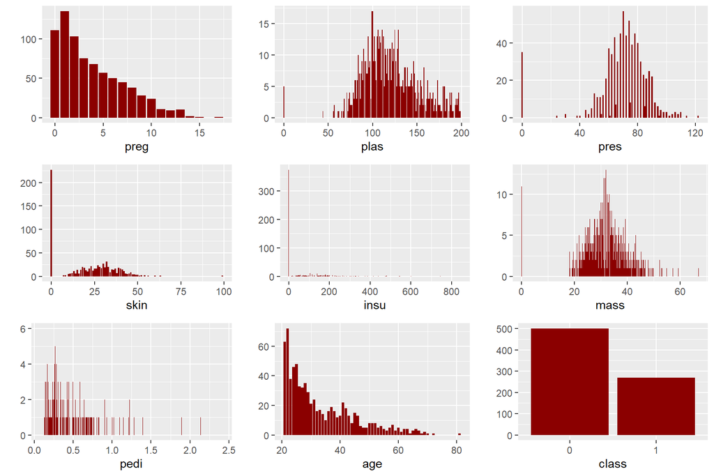

```r
library(ggplot2)
library(gridExtra)
variables <- names(diabetes)

plots <- lapply(variables, function(variable){
  ggplot(data=diabetes, aes_string(variable)) +
    geom_bar(fill='darkred') +
    ylab('')
})

grid.arrange(grobs=plots, ncol=3)
```

The classes ‘tested_negative’ and ‘tested positive’ are unbalanced, the first one being around twice as big as the latter.

The variables `preg` and `age` have simmilar distributions, which makes sense, as an older women is more likely to have been pregant more times.

As we can see, the variables `plas`, `pres`, `skin`, `insu` and `mass` contain 0 values that are clearly outliers. We have the right to suspect that those are hidden outliers.

## Visualisation of missing data

```r
diabetes_NA<-diabetes
diabetes_NA[diabetes_NA == 0] <- NA
diabetes_NA$preg[is.na(diabetes_NA$preg)] <- 0
diabetes_NA$insu[is.na(diabetes_NA$insu)] <- 0
diabetes_NA$class[is.na(diabetes_NA$class)] <- 0
```

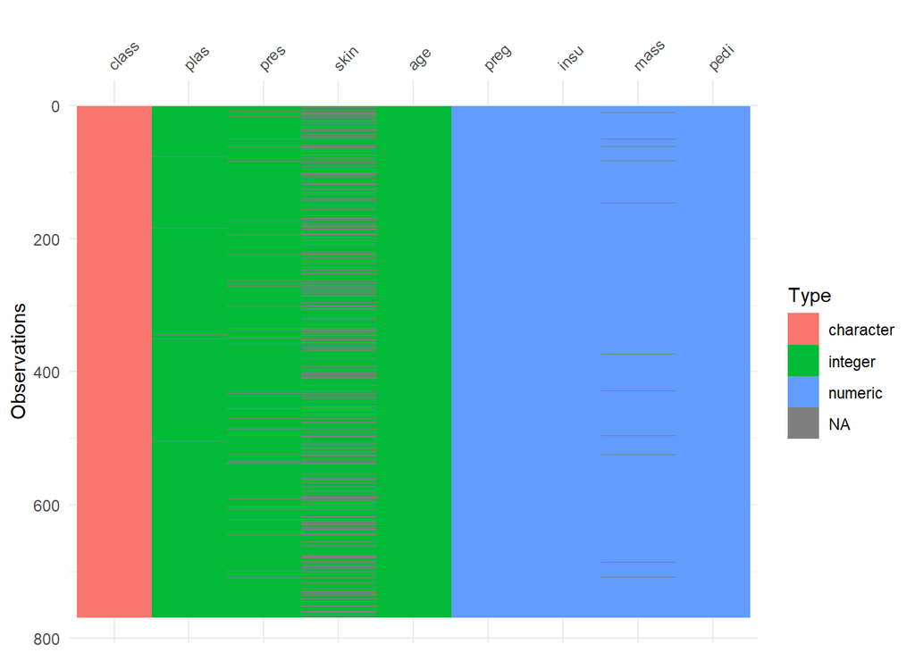

```r
visdat::vis_dat(diabetes_NA)
```

```r
knitr::kable(naniar::miss_var_summary(diabetes_NA), caption = "Procent of missing in dataset")
```

Procent of missing in dataset

| variable | n_miss | pct_miss |
| --- | --- | --- |
| skin | 227 | 29.5572917 |
| pres | 35 | 4.5572917 |
| mass | 11 | 1.4322917 |
| plas | 5 | 0.6510417 |
| preg | 0 | 0.0000000 |
| insu | 0 | 0.0000000 |
| pedi | 0 | 0.0000000 |
| age | 0 | 0.0000000 |
| class | 0 | 0.0000000 |

## Correlation heatmap

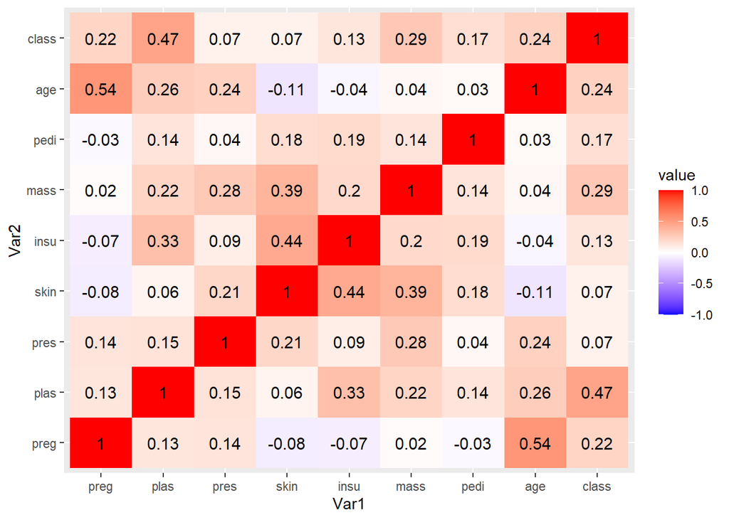

```r
diabetes$class <- as.numeric(diabetes$class)
diabetes_cor <- round(cor(diabetes),2)
diabetes_cor <- melt(diabetes_cor)
ggplot(data = diabetes_cor, aes(x=Var1, y=Var2, fill=value)) +
  scale_fill_gradient2(low = "blue", high = "red", mid = "white",
  midpoint = 0, limit = c(-1,1), space = "Lab")+
  geom_tile()+
  geom_text(aes(Var2, Var1, label = value), color = "black", size = 4)
```

## Example model

### Ranger

```r
m <- sample(1:nrow(diabetes), 0.7*nrow(diabetes))
diabetes_train <- diabetes[m,]
diabetes_test <- diabetes[-m,]
diabetes_train$class <- as.factor(diabetes_train$class)
classif_task <- makeClassifTask(id = "lvr", data = diabetes_train, target = "class")
classif_lrn <- makeLearner("classif.ranger", predict.type = "prob")
model <- mlr::train(classif_lrn, classif_task)
pred_test <- predict(model, newdata = diabetes_test)$data$prob.0
roc <- roc(diabetes_test$class, pred_test)
roc$auc
```

```
## Area under the curve: 0.818
```

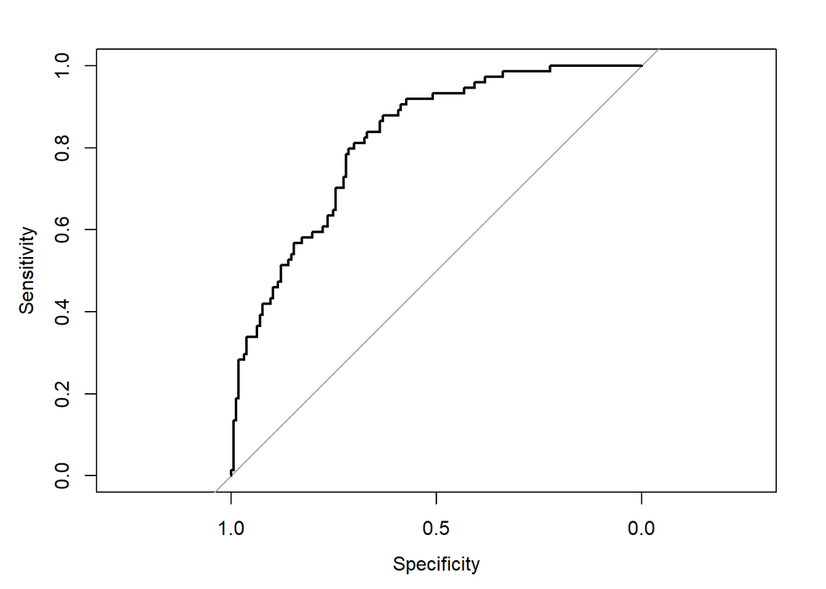

```r
plot(roc)
```

## Different datasets versions

```r
m <- sample(1:nrow(diabetes_NA), 0.7*nrow(diabetes_NA))
diabetes_train_NA <- diabetes_NA[m,]
diabetes_test_NA <- diabetes_NA[-m,]
```

### Omitting missing data

In this version we will simply omit all the missing data in the dataset.

```r
#train
diabetes_train_naomit<-na.omit(diabetes_train)
#test
diabetes_test_naomit<-na.omit(diabetes_test)

# displaying dataset dimensions
dim(diabetes_train_naomit)
```

```
## [1] 537   9
```

```r
dim(diabetes_test_naomit)
```

```
## [1] 231   9
```

### Imputation using mice

For this version we will use a simple mice imputation using PMM method.

```r
# train
imp_train1 <- mice(diabetes_train, method = "pmm", m = 1, maxit = 1, nnet.MaxNWts=3000)
```

```
##
##   1   1
```

```r
diabetes_train_mice <- mice::complete(imp_train1)

#test
imp_test1 <- mice(diabetes_test, method = "pmm", m = 1, maxit = 1, nnet.MaxNWts=3000)
```

```
##
##   1   1
```

```r
diabetes_test_mice <- mice::complete(imp_test1)

# displaying dataset dimensions
dim(diabetes_train_mice)
```

```
## [1] 537   9
```

```r
dim(diabetes_test_mice)
```

```
## [1] 231   9
```

### Skipping skin, insu and pres columns

```r
# train
diabetes_train_skip<-diabetes_train[,-c(3,4,5)]
imp_train2 <- mice(diabetes_train_skip, method = "pmm", m = 1, maxit = 1, nnet.MaxNWts=3000)
```

```
##
##   1   1
```

```r
diabetes_train_skip <- mice::complete(imp_train2)

#test
diabetes_test_skip<-diabetes_test_NA[,-c(3,4,5)]
imp_test2 <- mice(diabetes_test_skip, method = "pmm", m = 1, maxit = 1, nnet.MaxNWts=3000)
diabetes_test_skip <- mice::complete(imp_test2)

# displaying dataset dimensions
dim(diabetes_train_skip)
```

```
## [1] 537   6
```

```r
dim(diabetes_test_skip)
```

```
## [1] 231   6
```

## Checking performance of Ranger on datasets

To evaluate the performance we will use AUC, BalancedAccuracy and FalseNegativeRate - which will tell us how many patients the model assigns as healthy despite having diabetes.

```r
train_datasets<-list()
train_datasets[[1]]<-diabetes_train_naomit
train_datasets[[2]]<-diabetes_train_mice
train_datasets[[3]]<-diabetes_train_skip
train_datasets[[4]]<-diabetes_train
test_datasets<-list()
test_datasets[[1]]<-diabetes_test_naomit
test_datasets[[2]]<-diabetes_test_mice
test_datasets[[3]]<-diabetes_test_skip
test_datasets[[4]]<-diabetes_test
auc<-c(0,0,0,0)
FNR<-c(0,0,0,0)
BAC<-c(0,0,0,0)

for(i in 1:4){

  classif_task <- makeClassifTask(data = train_datasets[[i]],
                                  target = "class")
  classif_lrn <- makeLearner("classif.ranger",
                           predict.type = "prob")
  model <- mlr::train(classif_lrn, classif_task)
  prediction<- predict(model,
                       newdata = test_datasets[[i]])$data

  # auc
  auc[i] <- measureAUC(probabilities = prediction$prob.1,
                       truth = prediction$truth,
                       negative="0",
                       positive = "1")

  FNR[i] <- measureFNR(prediction$truth,
                       prediction$response,
                       negative="0",
                       positive = "1")
  BAC[i]<-measureBAC(prediction$truth,
                       prediction$response)

}
```

## Ranger Results

```r
results<-data.frame(AUC=auc, FalseNegativeRate=FNR, BalancedAccuracy=BAC)
row.names(results)<-c("naomit", "mice", "skip", "original")
results
```

```
##                AUC FalseNegativeRate BalancedAccuracy
## naomit   0.8162334         0.4189189        0.7109227
## mice     0.8143398         0.4324324        0.6946118
## skip     0.8108108         0.4324324        0.6977965
## original 0.8158031         0.4189189        0.7013686
```

The results are very similar and seem random (depend on seed).

## Data Skip

```
## Distribution not specified, assuming bernoulli ...
```

```
##                     AUC FalseNegativeRate BalancedAccuracy
## Ranger        0.9529989         0.1460674        0.8776705
## Ada           0.9119323         0.2359551        0.8186422
## Binomial      0.8396898         0.3595506        0.7498022
## GBM           0.8622409         0.3258427        0.7525716
## Naive Bayes   0.8544073         0.3707865        0.7406631
## Random forest 0.9698528         0.1123596        0.9156512
```

## Data Original

```
## Distribution not specified, assuming bernoulli ...
```

```
##                     AUC FalseNegativeRate BalancedAccuracy
## Ranger        0.8191599         0.4189189        0.7045533
## Ada           0.8127044         0.4189189        0.6981839
## Binomial      0.8214839         0.4729730        0.7030040
## GBM           0.8121019         0.4594595        0.6938371
## Naive Bayes   0.8115855         0.4324324        0.6946118
## Random forest 0.8153727         0.4189189        0.6981839
```

## Explanations

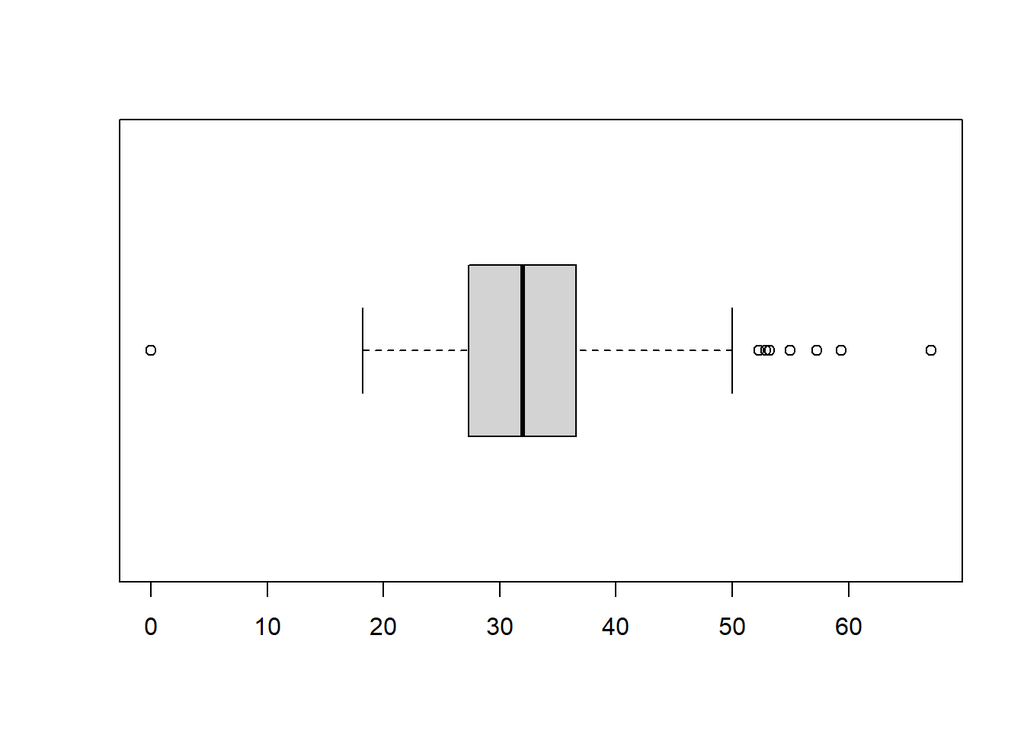

```r
boxplot(diabetes$mass, horizontal = TRUE)
```

```r
mean(diabetes$mass)
```

```
## [1] 31.99258
```

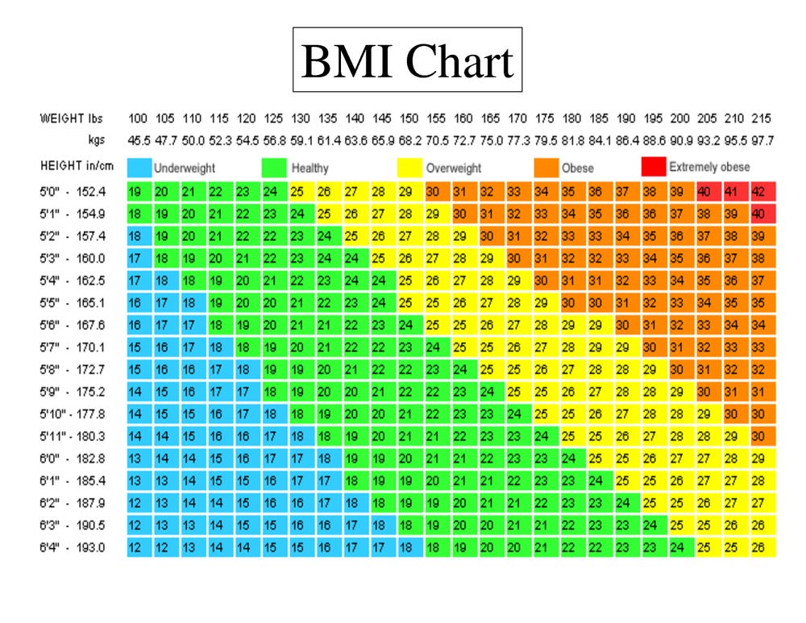

BMI chart

### Model ranger

```r
model_random_skip_ranger <- ranger::ranger(class~., data = diabetes_train_skip, classification = TRUE, probability = TRUE, num.trees=776, mtry=1, min.node.size=8, splitrule="extratrees")

samp <- sample(1:231, 5)
explainer <- explain(id= 'ranger', model = model_random_skip_ranger,
                     data = diabetes_test_skip[,-6],
             y = as.numeric(as.character(diabetes_test_skip$class)))
```

```
## Preparation of a new explainer is initiated
##   -> model label       :  ranger  (  default  )
##   -> data              :  231  rows  5  cols
##   -> target variable   :  231  values
##   -> predict function  :  yhat.ranger  will be used (  default  )
##   -> predicted values  :  No value for predict function target column. (  default  )
##   -> model_info        :  package ranger , ver. 0.12.1 , task classification (  default  )
##   -> predicted values  :  numerical, min =  0.01032563 , mean =  0.3793834 , max =  0.8407899
##   -> residual function :  difference between y and yhat (  default  )
##   -> residuals         :  numerical, min =  -0.6379025 , mean =  0.005897945 , max =  0.8765566
##   A new explainer has been created!
```

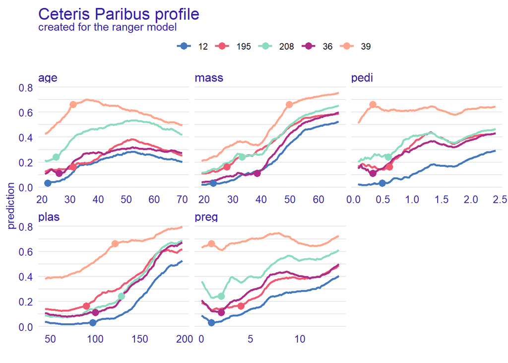

```r
cp_profile_1 <- predict_profile(explainer, diabetes_test_skip[samp,-6])
plot(cp_profile_1, color = "_ids_")
```

### Model ada

```r
classif_task <- makeClassifTask(id = "ada_tune_random", data = diabetes_train_skip, target = "class")
classif_lrn <- makeLearner("classif.ada", predict.type = "prob", par.vals = list(loss='logistic', type='discrete', iter=81, max.iter=3, minsplit=45, minbucket=4, maxdepth=1))
model_random_skip_ada<- mlr::train(classif_lrn, classif_task)
explainer_ada <- explain(id='Ada', model = model_random_skip_ada,
                     data = diabetes_test_skip[,-6],
             y = as.numeric(as.character(diabetes_test_skip$class)))
```

```
## Preparation of a new explainer is initiated
##   -> model label       :  WrappedModel  (  default  )
##   -> data              :  231  rows  5  cols
##   -> target variable   :  231  values
##   -> predict function  :  yhat.WrappedModel  will be used (  default  )
##   -> predicted values  :  No value for predict function target column. (  default  )
##   -> model_info        :  package mlr , ver. 2.19.0 , task classification (  default  )
##   -> predicted values  :  numerical, min =  0.004107252 , mean =  0.3502722 , max =  0.9689353
##   -> residual function :  difference between y and yhat (  default  )
##   -> residuals         :  numerical, min =  -0.9618177 , mean =  0.03500923 , max =  0.98599
##   A new explainer has been created!
```

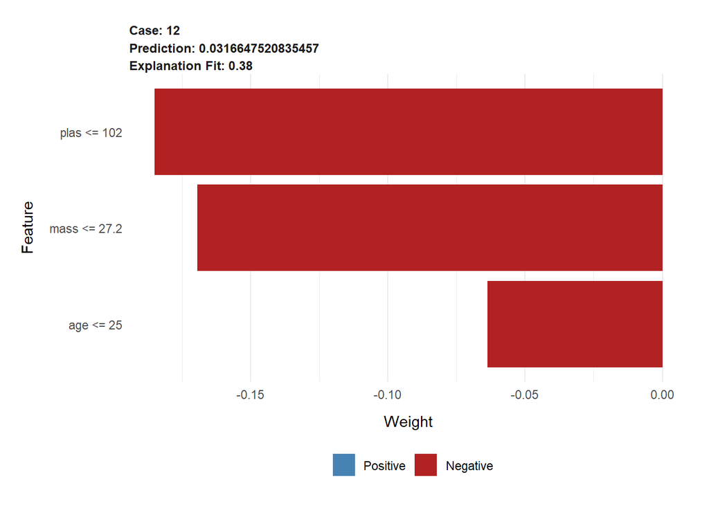

```r
model_type.dalex_explainer <- DALEXtra::model_type.dalex_explainer
predict_model.dalex_explainer <- DALEXtra::predict_model.dalex_explainer

lime_ranger1 <- predict_surrogate(
  explainer = explainer,
  new_observation = diabetes_test_skip[samp[1], -6],
  n_features = 3,
  n_permutations = 1000,
  type = "lime")

plot(lime_ranger1)
```

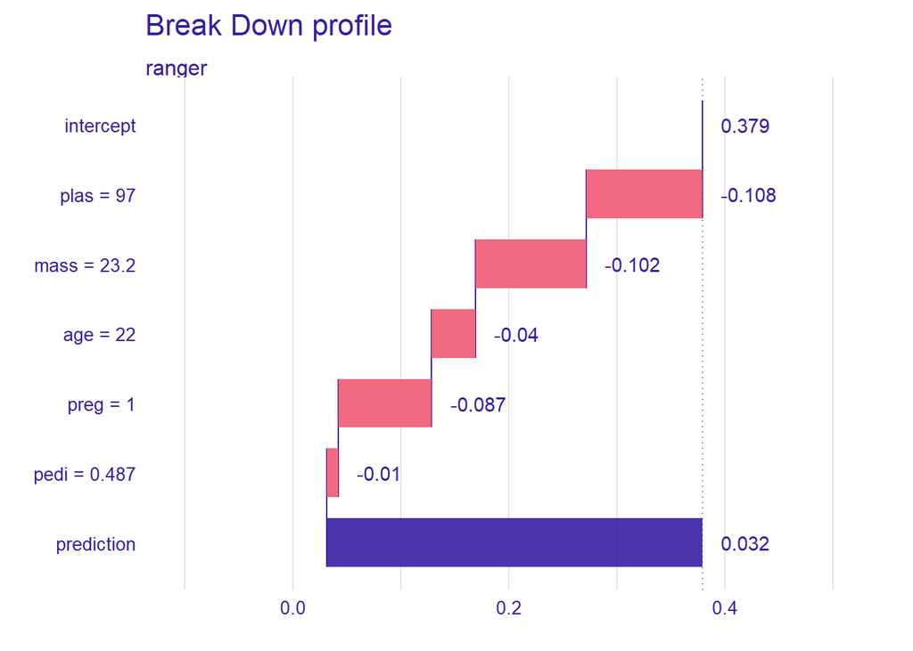

```r
pp_bd_1 <- predict_parts(explainer, new_observation = diabetes_test_skip[samp[1], -6], type = "break_down")
plot(pp_bd_1)
```

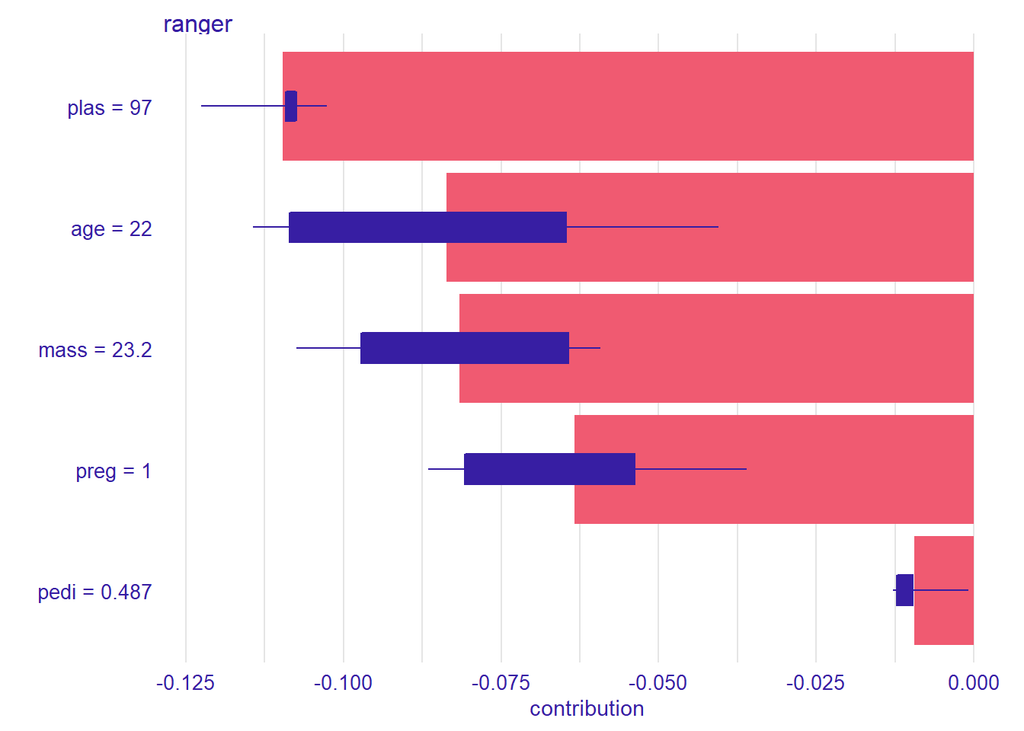

```r
pp_shap_1 <- predict_parts(explainer, new_observation = diabetes_test_skip[samp[1], -6], type = "shap", B = 5)
plot(pp_shap_1)
```

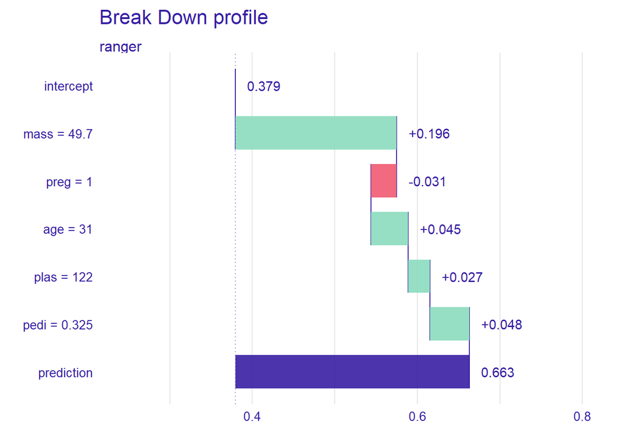

```r
pp_bd_1 <- predict_parts(explainer, new_observation = diabetes_test_skip[samp[2], -6], type = "break_down")
plot(pp_bd_1)
```

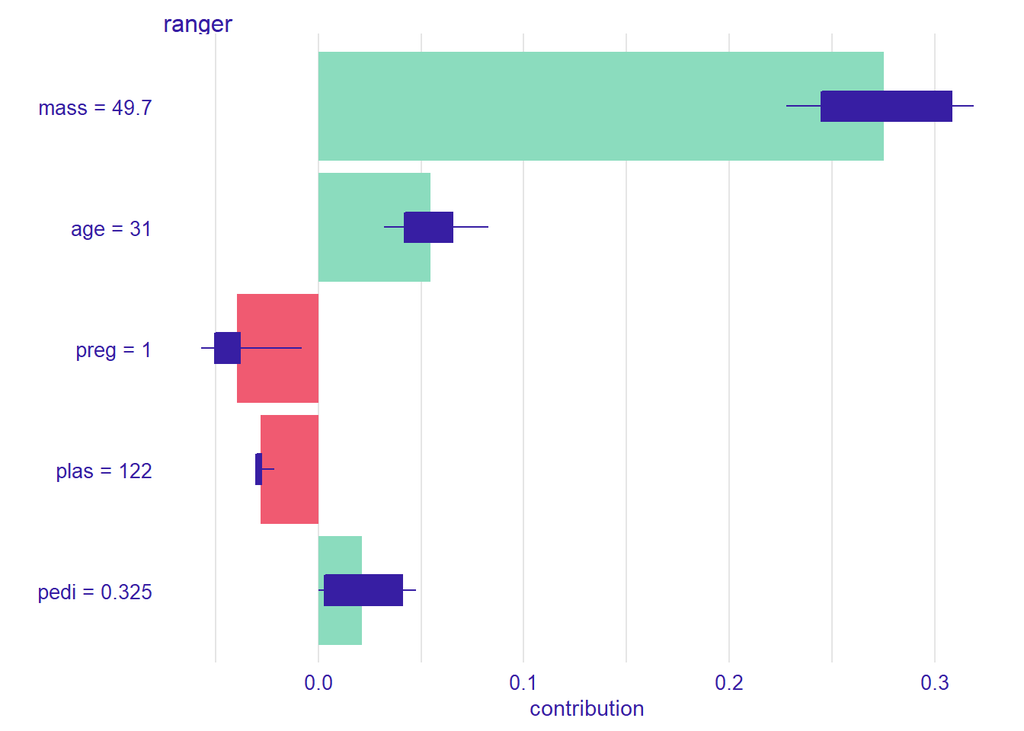

```r
pp_shap_1 <- predict_parts(explainer, new_observation = diabetes_test_skip[samp[2], -6], type = "shap", B = 5)
plot(pp_shap_1)
```

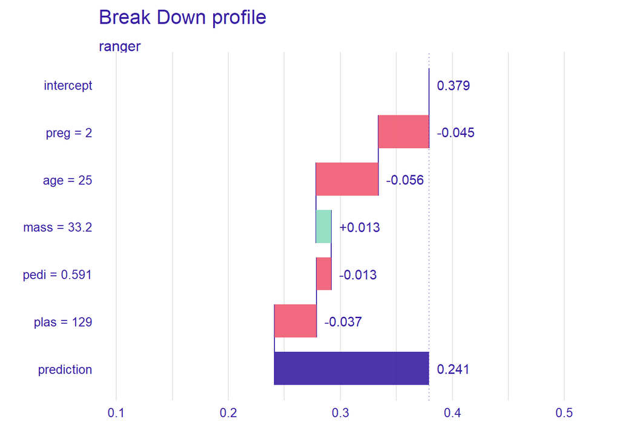

```r
pp_bd_1 <- predict_parts(explainer, new_observation = diabetes_test_skip[samp[3], -6], type = "break_down")
plot(pp_bd_1)
```

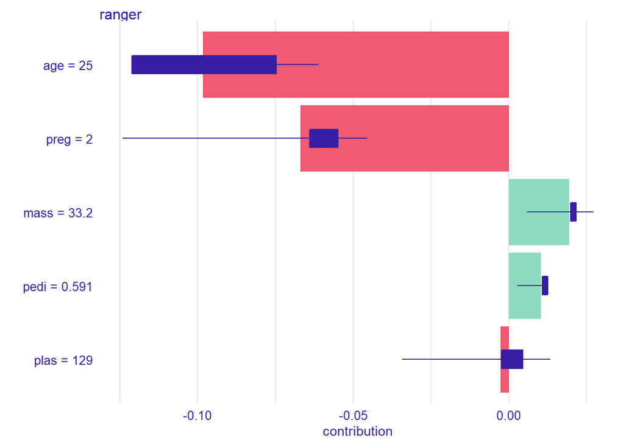

```r
pp_shap_1 <- predict_parts(explainer, new_observation = diabetes_test_skip[samp[3], -6], type = "shap", B = 5)
plot(pp_shap_1)
```

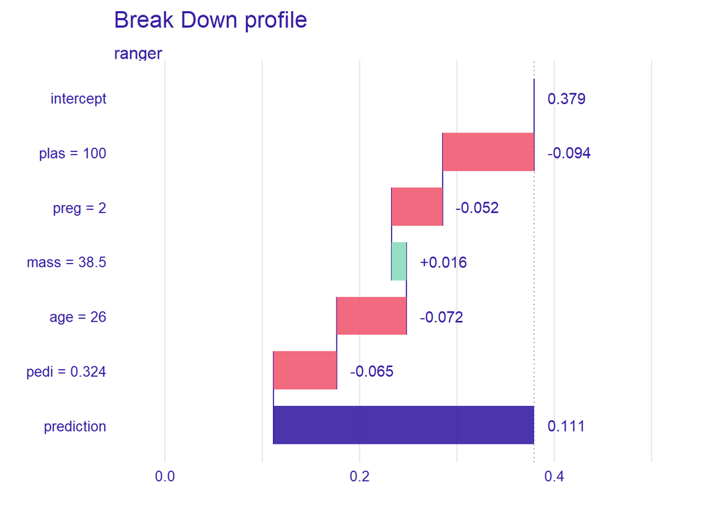

```r
pp_bd_1 <- predict_parts(explainer, new_observation = diabetes_test_skip[samp[4], -6], type = "break_down")
plot(pp_bd_1)
```

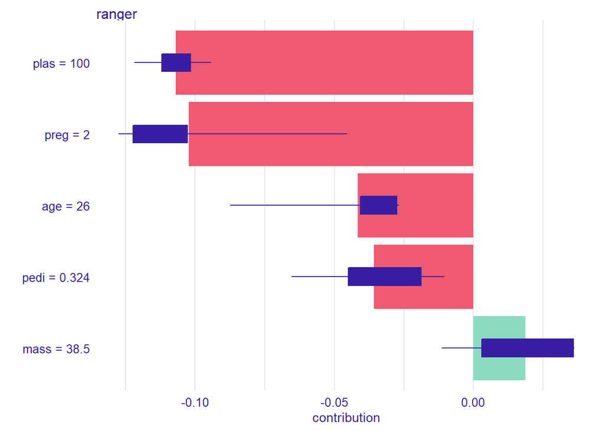

```r
pp_shap_1 <- predict_parts(explainer, new_observation = diabetes_test_skip[samp[4], -6], type = "shap", B = 5)
plot(pp_shap_1)
```

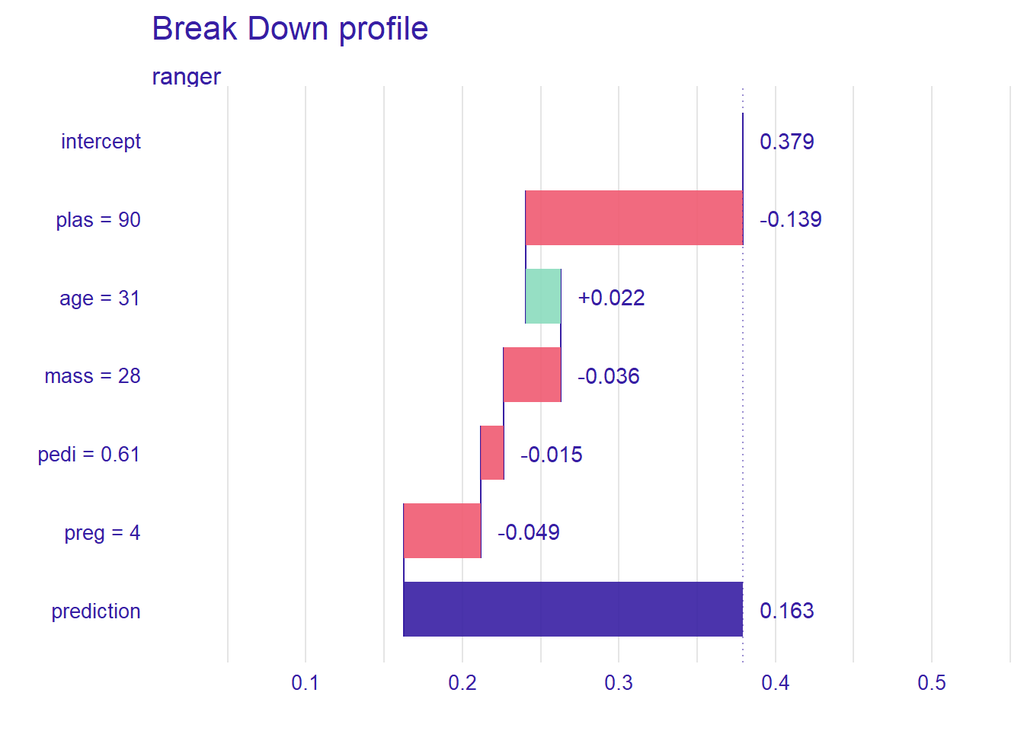

```r
pp_bd_1 <- predict_parts(explainer, new_observation = diabetes_test_skip[samp[5], -6], type = "break_down")
plot(pp_bd_1)
```

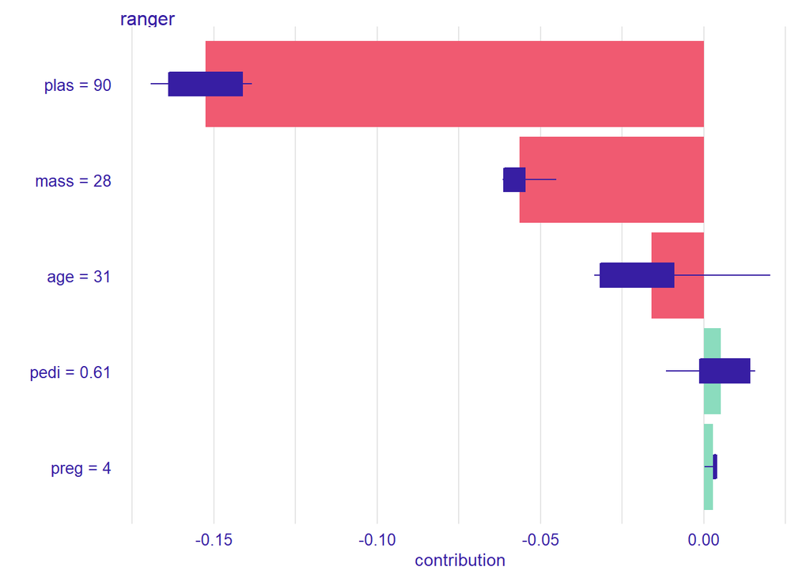

```r
pp_shap_1 <- predict_parts(explainer, new_observation = diabetes_test_skip[samp[5], -6], type = "shap", B = 5)
plot(pp_shap_1)
```

## Global Explanations

### Variable importance

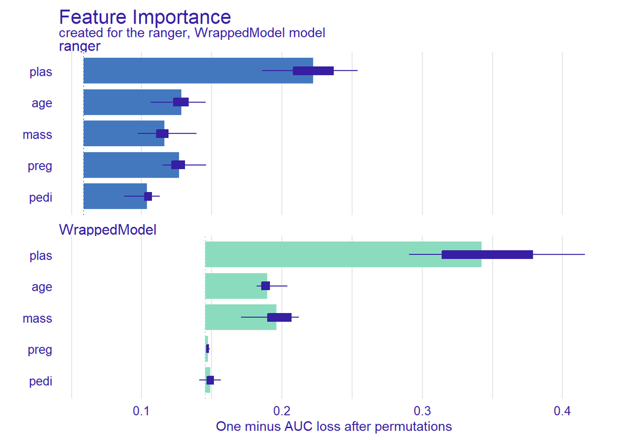

```r
fi_1 <- model_parts(explainer, B = 10)
fi_2 <- model_parts(explainer_ada, B = 10)
plot(fi_1, fi_2)
```

### Average influence on prediction

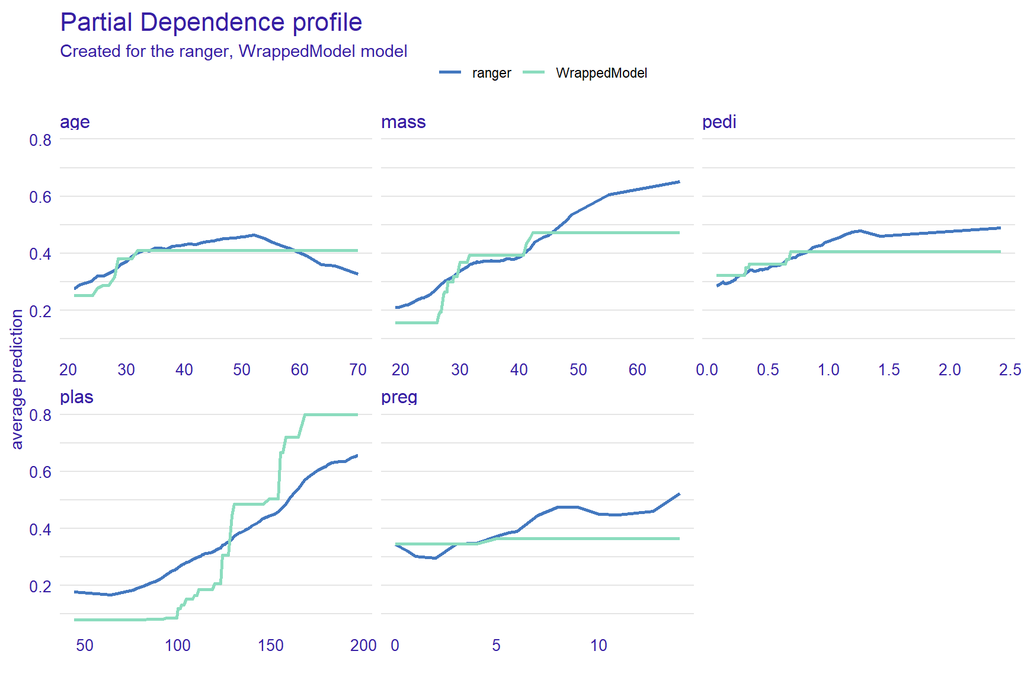

```r
pdp_1 <- model_profile(explainer)
pdp_2 <- model_profile(explainer_ada)

plot(pdp_1, pdp_2)
```

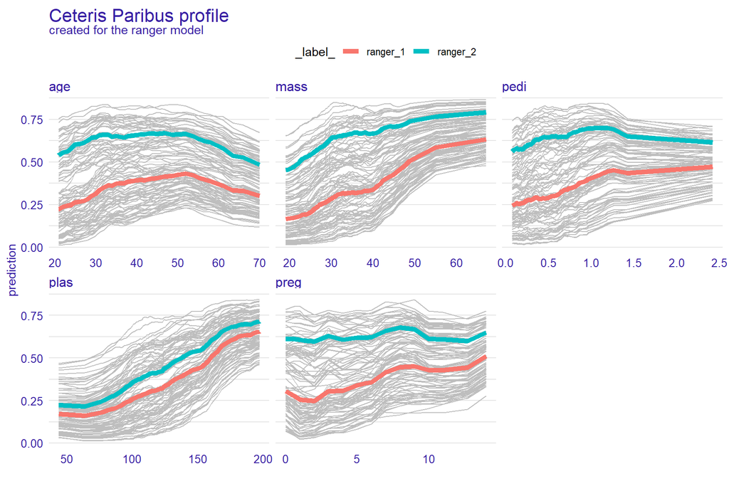

```r
pdp_3 <- model_profile(explainer,k=2)
pdp_4 <- model_profile(explainer_ada,k=2)
plot(pdp_3, geom = "profiles")
```

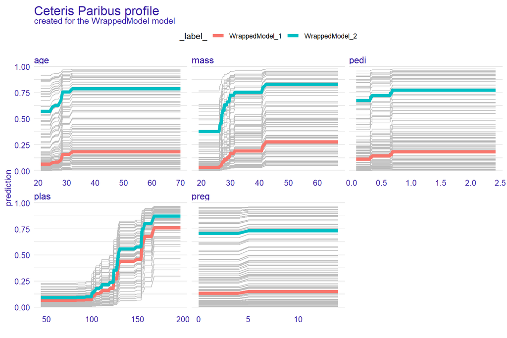

```r
plot(pdp_4, geom = "profiles")
```

### ALE

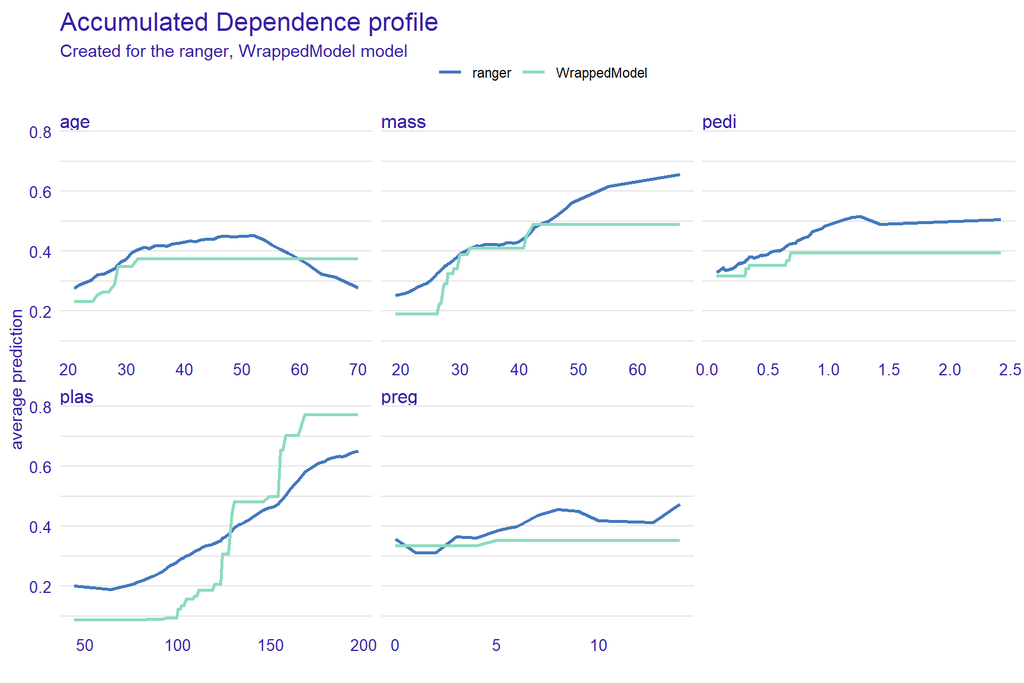

```r
ale_1 <- model_profile(explainer,type="accumulated")
ale_2 <- model_profile(explainer_ada,type="accumulated")

plot(ale_1, ale_2)
```

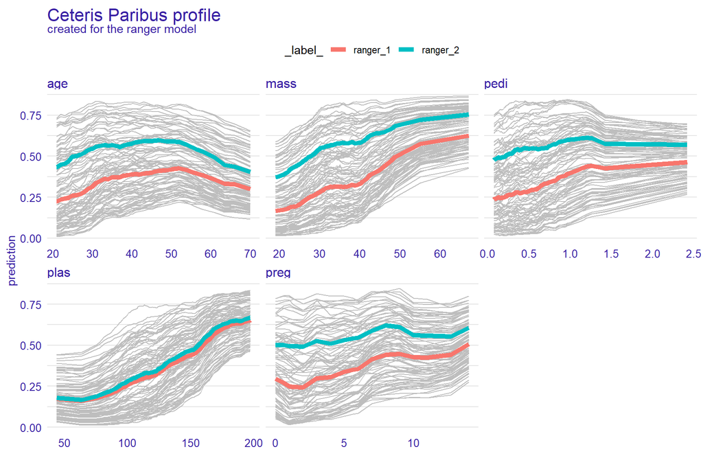

```r
ale_3 <- model_profile(explainer,k=2,type="accumulated")
ale_4 <- model_profile(explainer_ada,k=2,type="accumulated")

plot(ale_3, geom = "profiles")
```

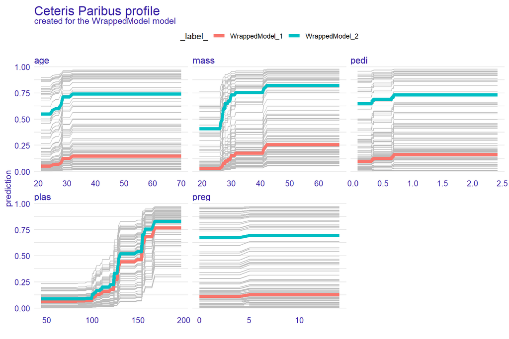

```r
plot(ale_4,geom = "profiles")
```

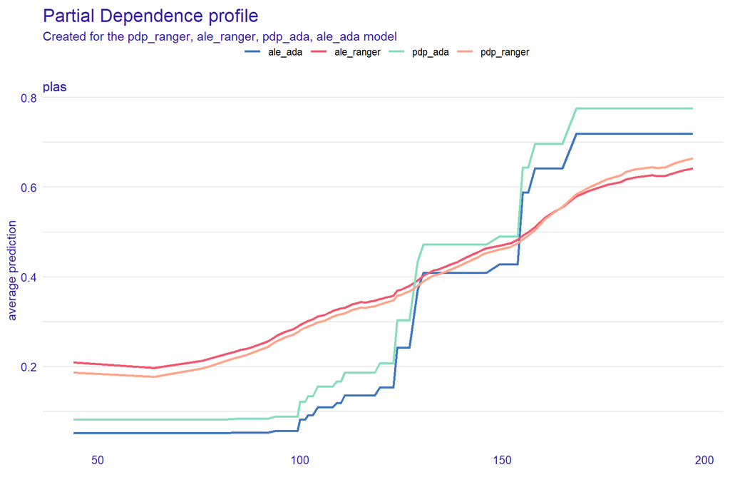

```r
pdp_4 <- model_profile(explainer, variables = "plas")
ale_4 <- model_profile(explainer, variables = "plas",type="accumulated")
ale_4$agr_profiles$`_label_` <- "ale_ranger"
pdp_4$agr_profiles$`_label_` <- "pdp_ranger"
pdp_5 <- model_profile(explainer_ada, variables = "plas")
ale_5 <- model_profile(explainer_ada, variables = "plas",type="accumulated")
ale_5$agr_profiles$`_label_` <- "ale_ada"
pdp_5$agr_profiles$`_label_` <- "pdp_ada"
plot(pdp_4,ale_4,pdp_5,ale_5)
```

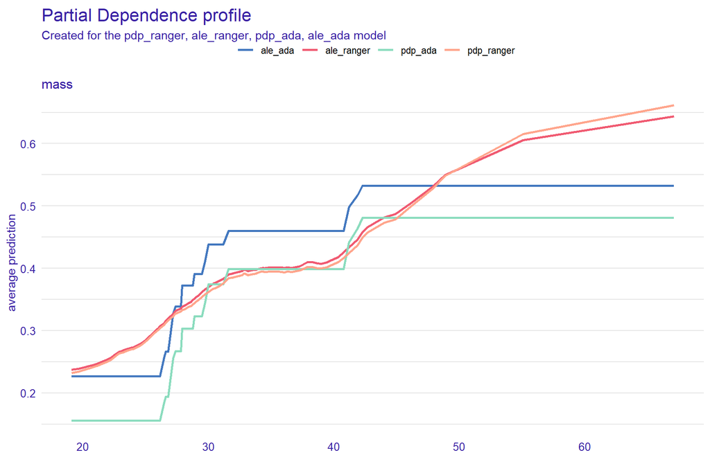

```r
pdp_4 <- model_profile(explainer, variables = "mass")
ale_4 <- model_profile(explainer, variables = "mass",type="accumulated")
ale_4$agr_profiles$`_label_` <- "ale_ranger"
pdp_4$agr_profiles$`_label_` <- "pdp_ranger"
pdp_5 <- model_profile(explainer_ada, variables = "mass")
ale_5 <- model_profile(explainer_ada, variables = "mass",type="accumulated")
ale_5$agr_profiles$`_label_` <- "ale_ada"
pdp_5$agr_profiles$`_label_` <- "pdp_ada"
plot(pdp_4,ale_4,pdp_5,ale_5)
```